# Statystyka I z R Warsztat 6. Parametry rozproszenia

Tomasz Żółtak

14 listopada 2016

Na dzisiejszych zajęciach poznamy funkcje pozwalające obliczyć typowo wykorzystywane parametry parametry rozproszenia zmiennych statystycznych.

# Wczytanie danych

```r
> try(setwd("warsztat 2016.11.14"), silent = TRUE)
> nazwyObiektow = load("dane_2016.11.14.RData")
> nazwyObiektow
 [1] "schoolType"           "sex"                  "age"
 [4] "scoreTMR"             "scoreKKS"             "scoreKNS"
 [7] "scorePISAMath"        "scorePISARead"        "scorePISAScie"
[10] "noPersHous"           "hisei"                "parEdu"
[13] "wealth"               "income"               "variablesDescription"
> variablesDescription
                                            schoolType
                                 "School type (track)"
                                                   sex
                                      "Sex of student"
                                                   age
                         "How old student was in 2009"
                                              scoreTMR
   "Score on Raven's Progressive Matrices test [0-60]"
                                              scoreKKS
        "Score on Cultural Competences Scale [60-240]"
                                              scoreKNS
           "Score on Snyder's Adult Hope Scale [8-64]"
                                         scorePISAMath
"Score on PISA mathematics test (pseudoEAP estimator)"
                                         scorePISARead
    "Score on PISA reading test (pseudoEAP estimator)"
                                         scorePISAScie
    "Score on PISA science test (pseudoEAP estimator)"
                                            noPersHous
                    "Number of persons in a household"
                                                 hisei
                "Highest parental occupational status"
                                                parEdu
                 "Highest parental education in years"
                                                wealth
                                              "Wealth"
                                                income
                             "Houshold monthly income"
```

# Parametry rozproszenia

## Rozstęp i odchylenie ćwiartkowe

W R nie mamy funkcji pozwalającej bezpośrednio obliczyć rozstęp, niemniej zrobienie tego samemu jest oczywiście banalnie proste. Z kolei funkcja `IQR()`, służąca obliczeniu odchylenia ćwiartkowego robi to nieco inaczej, niż w typowych (stosowanych w Polsce) definicjach (nie dzieli różnicy wartości 3. i 1. kwartyla przez dwa). Niemniej obliczenie samemu odchylenia ćwiartkowego również nie nastręcza trudności (jeśli umiemy obliczyć kwartyle).

```r
> # rozstęp
> max(scoreTMR, na.rm = TRUE) - min(scoreTMR, na.rm = TRUE)
[1] 49
> # odchylenie ćwiartkowe
> IQR(scoreTMR, na.rm = TRUE) / 2
[1] 4.5
> # równoważnie
> q = quantile(scoreTMR, na.rm = TRUE)
> q
  0%  25%  50%  75% 100%
  11   45   50   54   60
> (q[4] - q[2]) / 2
75%
4.5
```

## Wariancja i odchylenie standardowe

Do obliczenia wariancji i odchylenia standardowego domyślnie wykorzystue się w R funkcje odpowiednio `var()` i `sd()`. W praktyce jest jednak z nimi pewien problem, bowiem **zwracają one wartości, które są nieobciążonymi przewidywaniami (odpowiednio wariancji i odchylenia standardowego), jeśli zadany im wektor traktować jako prostą próbę losową z populacji, dla której chcemy oszacować wartość danego parametru**.

Od strony technicznej oznacza to, że w przypadku wariancji suma kwadratów różnic od średniej jest dzielona nie przez liczbę elmentów wektora, lecz przez liczbę elementów pomniejszoną o jeden. Jeśli wektor jest długi, robi to niewielką różnicę, jednak jeśli jest krótki, będzie ona bardzo wyraźna.

```r
> x = 0:10  # niewielka liczba obserwacji
> y = rep(x, 10)  # spora liczba obserwacji
> z = rep(x, 100)  # duża liczba obserwacji
> srednie = c(x = mean(x), y = mean(y), z = mean(z))
> # wariancja obliczona jako oszacowanie na podstawie prostej próby losowej
> warOszac = c(x = var(x), y = var(y), z = var(z))
> # wariancja obliczona na całej populacji (jeden ze sposobów)
> warPopul = c(x = mean(x^2) - mean(x)^2, y = mean(y^2) - mean(y)^2,
+              z = mean(z^2) - mean(z)^2)
> # porównajmy
> round(rbind(srednie, warOszac, warPopul), 1)
          x    y  z
srednie   5  5.0  5
warOszac 11 10.1 10
warPopul 10 10.0 10
> # to się w ogóle nie uda!
> var(1)
[1] NA
```

Jeśli chcemy uzyskać *normalną* wariancję/odchylenie standardowe musimy więc obliczyć ją sobie sami, lub skorygować wynik działania funkcji `var()` lub `sd()`:

1. Wariancja policzona *na piechotę* ze wzoru definicyjnego:

```r
> varTMR = mean((scoreTMR - mean(scoreTMR, na.rm = TRUE))^2, na.rm = TRUE)
> sdTMR = varTMR^0.5
> varTMR
[1] 54.03407
> sdTMR
[1] 7.350787
> # dla porównania
> var(scoreTMR, na.rm = TRUE)
[1] 54.04975
> sd(scoreTMR, na.rm = TRUE)
[1] 7.351854
```

2. Wariancja policzona *na piechotę* z alternatywnego wzoru, jako różnica średniej kwadratów wartości zmiennej i kwadratu średniej tej zmiennej:

```r
> var2TMR = mean(scoreTMR^2, na.rm = TRUE) - mean(scoreTMR, na.rm = TRUE)^2
> sd2TMR = var2TMR^0.5
> var2TMR
[1] 54.03407
> sd2TMR
[1] 7.350787
```

3. Skorygowanie (przeliczenie) wyników działania funkcji `var()` lub `sd()`:

```r
> poprawka = (length(scoreTMR) - 1) / length(scoreTMR)
> poprawka
[1] 0.9997366
> var(scoreTMR, na.rm = TRUE) * poprawka
[1] 54.03551
> sd(scoreTMR, na.rm = TRUE) * poprawka^0.5
[1] 7.350885
```

## Współczynnik zmienności

Współczynniki zmienności są często bardziej użyteczną miarą zróżnicowania w przypadku zmiennych mierzonych na skalach ilorazowych, które przyjmują tylko wartości nieujemne, a więc mają zakres wartości ograniczony z jednej strony, ale otwarty z drugiej. Pozwalają bowiem uwzględnić, że w takim przypadku w ramach grupy o wysokiej średniej wartości zmiennej jest znacznie więcej *miejsca* na różnicowanie się wartości, niż w ramach grupy, w której średnia wartości tej zmiennej jest niska, a więc bliska granicy zakresu możliwych do przyjęcia wartości.

Najszerzej wykorzystywany typ wskaźnika zmieności obliczamy dzieląc wartość odchylenia standardowego przez wartość średniej.

Aby prześledzić opisane wyżej własności współczynika zmienności w stosunku do odchylenia standardowego, rozpatrzmy dwie zmienne: `x` i `y`, które mogą przyjmować tylko wartości nieujemne i są określone w 10-cio elementowej zbiorowości. Przyjmiemy przy tym arbitralnie, że średnia zmiennej `x` wynosi 1, a średnia zmiennej `y` wynosi 10. Następnie dobierzemy wartości tych zmiennych dla poszczególnych jednostek zbiorowości w ten sposób, aby zmaksymalizować wartość odchylenia standardowego (w ramach przyjętych założeń, że zmienne mają opisane wyżej średnie i nie mogą przyjmować wartości ujemnych).

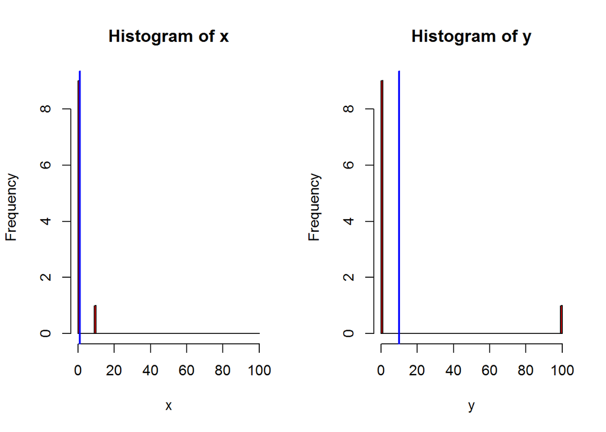

```r
> # dla 10-cio elementowej zbiorowości odch. std. zm. x i y maksymalizuje
> #   takie przypisanie wartości tych zmiennych:
> x = c(rep(0, 9), 10)
> y = c(rep(0, 9), 100)
> # obejrzyjmy rozkłady (pionowa niebieska linia wskazuje średnią)
> par(mfcol = c(1, 2))
> hist(x, xlim = c(0, 100), breaks = 0:100, col = 2)
> abline(v = mean(x), lwd = 2, col = 4)
> hist(y, xlim = c(0, 100), breaks = 0:100, col = 2)
> abline(v = mean(y), lwd = 2, col = 4)
```

```r
> # obliczmy parametry rozkładów tych zmiennych
> srednie = c(x = mean(x), y = mean(y))
> odchStd = c(x = mean(x^2) - mean(x)^2, y = mean(y^2) - mean(y)^2)^0.5
> round(rbind(srednie, odchStd), 1)
        x  y
srednie 1 10
odchStd 3 30
> # jak widać, odchylenia standardowe dramatycznie się różnią
> wspZm = odchStd / srednie
> round(rbind(srednie, odchStd, wspZm), 1)
        x  y
srednie 1 10
odchStd 3 30
wspZm   3  3
> # ale współczynniki zmienności są już takie same
```

#### Zadanie

Jaka zmienna/zmienne spośród wczytanych na początku zajęć spełnia warunki umożliwiające policzenie współczynnika zmienności? Odpowiedz na podstawie opisu zmiennych i wartości parametrów wartości (kod poniżej).

```r
> variablesDescription
                                            schoolType
                                 "School type (track)"
                                                   sex
                                      "Sex of student"
                                                   age
                         "How old student was in 2009"
                                              scoreTMR
   "Score on Raven's Progressive Matrices test [0-60]"
                                              scoreKKS
        "Score on Cultural Competences Scale [60-240]"
                                              scoreKNS
           "Score on Snyder's Adult Hope Scale [8-64]"
                                         scorePISAMath
"Score on PISA mathematics test (pseudoEAP estimator)"
                                         scorePISARead
    "Score on PISA reading test (pseudoEAP estimator)"
                                         scorePISAScie
    "Score on PISA science test (pseudoEAP estimator)"
                                            noPersHous
                    "Number of persons in a household"
                                                 hisei
                "Highest parental occupational status"
                                                parEdu
                 "Highest parental education in years"
                                                wealth
                                              "Wealth"
                                                income
                             "Houshold monthly income"
> summary(cbind(age, scoreTMR, scoreKKS, scoreKNS, scorePISAMath, scorePISARead,
+               scorePISAScie, noPersHous, wealth, income, parEdu, hisei))
      age           scoreTMR        scoreKKS        scoreKNS
 Min.   :15.79   Min.   :11.00   Min.   : 60.0   Min.   : 8.00
 1st Qu.:17.17   1st Qu.:45.00   1st Qu.:162.0   1st Qu.:43.00
 Median :17.45   Median :50.00   Median :178.0   Median :48.00
 Mean   :17.47   Mean   :48.54   Mean   :178.3   Mean   :47.74
 3rd Qu.:17.72   3rd Qu.:54.00   3rd Qu.:195.0   3rd Qu.:53.00
 Max.   :20.21   Max.   :60.00   Max.   :240.0   Max.   :64.00
 NA's   :322     NA's   :350     NA's   :325     NA's   :337
 scorePISAMath   scorePISARead   scorePISAScie     noPersHous
 Min.   :199.2   Min.   :231.7   Min.   :226.8   Min.   : 2.000
 1st Qu.:457.2   1st Qu.:467.3   1st Qu.:473.9   1st Qu.: 4.000
 Median :528.2   Median :534.8   Median :538.6   Median : 4.000
 Mean   :523.5   Mean   :524.5   Mean   :531.0   Mean   : 4.536
 3rd Qu.:588.2   3rd Qu.:589.0   3rd Qu.:596.2   3rd Qu.: 5.000
 Max.   :793.7   Max.   :749.1   Max.   :756.3   Max.   :14.000
                                                 NA's   :86
     wealth            income           parEdu          hisei
 Min.   :-2.8256   Min.   : 1.136   Min.   : 3.00   Min.   :16.00
 1st Qu.:-0.7216   1st Qu.: 5.305   1st Qu.:11.00   1st Qu.:33.00
 Median :-0.2500   Median : 7.494   Median :11.00   Median :43.00
 Mean   :-0.1678   Mean   : 9.598   Mean   :12.34   Mean   :45.86
 3rd Qu.: 0.2512   3rd Qu.:10.818   3rd Qu.:12.00   3rd Qu.:55.00
 Max.   : 2.7703   Max.   :68.456   Max.   :16.00   Max.   :90.00
 NA's   :9         NA's   :9        NA's   :43      NA's   :111
```

Oblicz wartość współczynnika zmienności dla tej zmiennej (zmienych).

```r
> # to jest miejsce na TWój kod
```

## Odchylenie przeciętne od mediany

#### Zadanie

Oblicz odchylenie przeciętne od mediany zmiennej `scoreTMR`, pamiętając że:

- Odchylenie przeciętne od mediany to średnia modułóW różnic pomiędzy wartością zmiennej dla danej jednostki obserwacji a wartością mediany.
- Do obliczenia modułu liczby można wykorzystać funkcję `abs()`.

```r
> # to jest miejsce na Twój kod
> mean(abs(scoreTMR - median(scoreTMR, na.rm = TRUE)), na.rm = TRUE)
[1] 5.468369
>
> scoreTMRbbd = na.omit(scoreTMR)
> mean(abs(scoreTMRbbd - median(scoreTMRbbd)))
[1] 5.468369
```

# Podsumowanie informacji o skalach pomiarowych i podstawowych parametrach statystycznych

| typ skali | przykładowe zmienne | sensowne operacje | dominanta (modalna) | mediana (kwantyle) | średnia | rozstęp (odch. ćwiart.) | odch. przec. od mediany | wariancja (odch. std.) | współcz. zmienności |
| --- | --- | --- | --- | --- | --- | --- | --- | --- | --- |
| nominalna | płeć, wyznanie, narodowość | =, != | V | - | - | - | - | - | - |
| porządkowa | poziom wykształcenia, preferencje, pozycja w hierarchii, ranking (czegośtam), odpowiedź w ankiecie na skali „tak”, „raczej tak”, … | =, !=, >, < | V | V | - | - | - | - | - |
| przedziałowa | stopnie C, data kalendarzowa, skale standardowe | =, !=, >, <, różnice | V* | V | V | V | V | V | - |
| ilorazowa | zarobki, odległości, wiek | =, !=, >, <, różnice**, ilorazy | V* | V | V | V | V | V | V |
| absolutna | liczba osób, liczba zdarzeń | =, !=, >, <, różnice, ilorazy | V* | V | V | V | V | V | V |

* Dla skal przedziałowych, ilorazowych i absolutnych obliczenie modalnej jest zawsze poprawne formalnie, ale jeśli zmienna może przyjmować bardzo wiele wartości (zwłaszcza jeśli w analizowanej zbiorowości jest niewiele obserwacji), może to mieć znikomą wartość informacyjną. W skrajnym przypadku każda jednostka obserwacji będzie mieć inną wartość zmiennej i każda z tych wartości będzie modalną.

** W przypadku zmiennych mierzonych na skalach ilorazowych, które przyjmują tylko wartości nieujemne analizowanie różnic ma często mniejszy sens, niż analizowanie ilorazów (stosunków). Np. załóżmy, że porównujemy zarobki dwóch osób w dwóch punktach czasu i że dla każdej z tych osób jej zarobki wzrastały w analizowanym okresie proporcjonalnie do inflacji - w efekcie stosunek zarobków tych dwóch osób będzie cały czas ten sam, chociaż różnica zarobków się zwiększy (zakładając, że inflacja była niezerowa).

# Na następne zajęcia

## Praca domowa

Zostanie nadesłana mailem.

## Do przeczytania na następne zajęcia

Zostanie nadesłana mailem.